# k-NN Explorer: Building Intuition Through Practice - SOLUTIONS

## Part 3: k-NN vs Logistic Regression Showdown (15 minutes)

We’ll create three datasets and compare both methods.

### Task 3.1: Generate Three Challenging Datasets

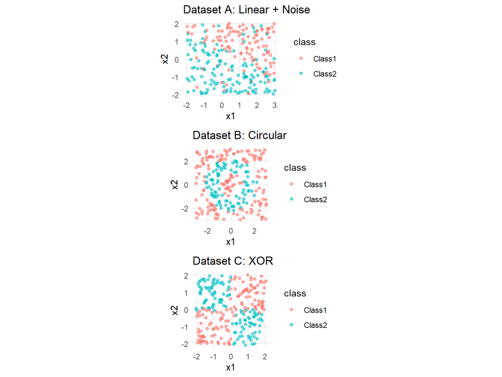

```r
# Dataset A: Linear boundary with noise
set.seed(300)
n <- 250
# Create linearly separable data with some noise
# Boundary should be roughly: x1 + 2*x2 > 1
x1_a <- runif(n, -2, 3)
x2_a <- runif(n, -2, 2)
y_a <- ifelse(x1_a + 2*x2_a > 1, "Class1", "Class2")

# Add 15% noise (flip some labels randomly)
noise_indices <- sample(1:n, size = floor(0.15 * n))
y_a[noise_indices] <- ifelse(y_a[noise_indices] == "Class1", "Class2", "Class1")

data_a <- data.frame(x1 = x1_a, x2 = x2_a, class = factor(y_a))

# Dataset B: Circular/ring pattern
set.seed(400)
x1_b <- runif(n, -3, 3)
x2_b <- runif(n, -3, 3)
radius <- sqrt(x1_b^2 + x2_b^2)
y_b <- ifelse(radius < 1, "Class1",
              ifelse(radius < 2.2, "Class2", "Class1"))

data_b <- data.frame(x1 = x1_b, x2 = x2_b, class = factor(y_b))

# Dataset C: XOR pattern (most challenging!)
set.seed(500)
x1_c <- runif(n, -2, 2)
x2_c <- runif(n, -2, 2)
# XOR logic: same sign = Class1, different signs = Class2
y_c <- ifelse((x1_c > 0 & x2_c > 0) | (x1_c < 0 & x2_c < 0), "Class1", "Class2")

# Add gaussian noise to make it more realistic
x1_c <- x1_c + rnorm(n, 0, 0.1)
x2_c <- x2_c + rnorm(n, 0, 0.1)

data_c <- data.frame(x1 = x1_c, x2 = x2_c, class = factor(y_c))

# Plot all three datasets
p1 <- ggplot(data_a, aes(x = x1, y = x2, color = class)) +
  geom_point(alpha = 0.6) + labs(title = "Dataset A: Linear + Noise") +
  theme_minimal() + coord_fixed()

p2 <- ggplot(data_b, aes(x = x1, y = x2, color = class)) +
  geom_point(alpha = 0.6) + labs(title = "Dataset B: Circular") +
  theme_minimal() + coord_fixed()

p3 <- ggplot(data_c, aes(x = x1, y = x2, color = class)) +
  geom_point(alpha = 0.6) + labs(title = "Dataset C: XOR") +
  theme_minimal() + coord_fixed()

grid.arrange(p1, p2, p3, ncol = 1)
```

### Task 3.2: Model Comparison Function

Complete this function to compare k-NN and logistic regression:

```r
compare_methods <- function(data, dataset_name) {
  # Create 70/30 train/test split
  n <- nrow(data)
  train_idx <- sample(1:n, round(0.7 * n))

  train_data <- data[train_idx, ]
  test_data <- data[-train_idx, ]

  train_features <- train_data[, c("x1", "x2")]
  test_features <- test_data[, c("x1", "x2")]
  train_labels <- train_data$class
  test_labels <- test_data$class

  # Scale features for k-NN
  train_scaled <- scale(train_features)
  test_scaled <- scale(test_features,
                      center = attr(train_scaled, "scaled:center"),
                      scale = attr(train_scaled, "scaled:scale"))

  # Fit logistic regression
  log_model <- glm(class ~ x1 + x2, data = train_data, family = binomial)
  log_pred_prob <- predict(log_model, test_features, type = "response")
  log_pred <- ifelse(log_pred_prob > 0.5, levels(test_labels)[2], levels(test_labels)[1])
  log_pred <- factor(log_pred, levels = levels(test_labels))
  log_accuracy <- mean(log_pred == test_labels)

  # Fit k-NN with k=5
  knn_pred <- knn(train = train_scaled,
                 test = test_scaled,
                 cl = train_labels,
                 k = 5)
  knn_accuracy <- mean(knn_pred == test_labels)

  # Return results dataframe
  results <- data.frame(
    Method = c("Logistic Regression", "k-NN (k=5)"),
    Dataset = rep(dataset_name, 2),
    Accuracy = c(log_accuracy, knn_accuracy)
  )

  return(results)
}
```

### Task 3.3: Run the Competition

```r
# Test all three datasets
results_a <- compare_methods(data_a, "Linear")
results_b <- compare_methods(data_b, "Circular")
results_c <- compare_methods(data_c, "XOR")

# Combine results
all_results <- rbind(results_a, results_b, results_c)
print("Performance Comparison Across Datasets:")
```

```
## [1] "Performance Comparison Across Datasets:"
```

```r
print(all_results)
```

```
##                Method  Dataset  Accuracy
## 1 Logistic Regression   Linear 0.8533333
## 2          k-NN (k=5)   Linear 0.8666667
## 3 Logistic Regression Circular 0.5866667
## 4          k-NN (k=5) Circular 0.9466667
## 5 Logistic Regression      XOR 0.4800000
## 6          k-NN (k=5)      XOR 0.9733333
```

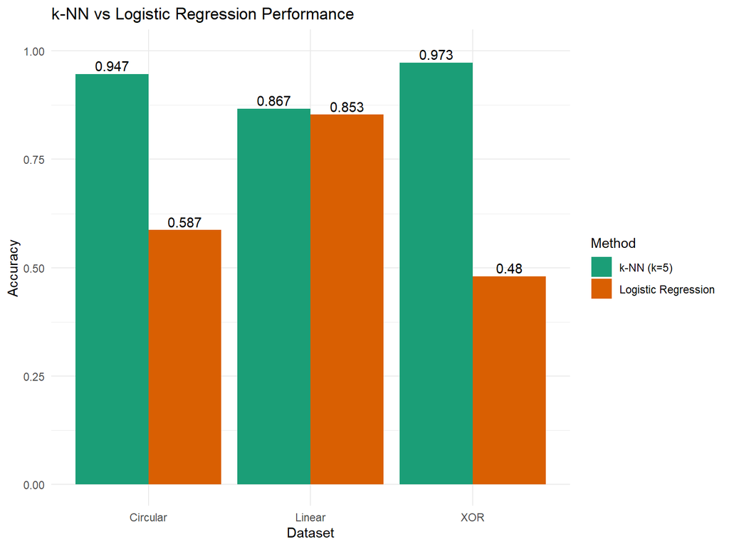

```r
# Create comparison plot
ggplot(all_results, aes(x = Dataset, y = Accuracy, fill = Method)) +
  geom_bar(stat = "identity", position = "dodge") +
  geom_text(aes(label = round(Accuracy, 3)),
            position = position_dodge(width = 0.9),
            vjust = -0.3) +
  labs(title = "k-NN vs Logistic Regression Performance",
       y = "Accuracy") +
  theme_minimal() +
  ylim(0, 1) +
  scale_fill_brewer(type = "qual", palette = 2)
```

```r
# Summary of results
summary_stats <- all_results %>%
  group_by(Method) %>%
  summarise(
    Mean_Accuracy = mean(Accuracy),
    Best_Dataset = Dataset[which.max(Accuracy)],
    Worst_Dataset = Dataset[which.min(Accuracy)]
  )

print("Method Summary:")
```

```
## [1] "Method Summary:"
```

```r
print(summary_stats)
```

```
## # A tibble: 2 × 4
##   Method              Mean_Accuracy Best_Dataset Worst_Dataset
##   <chr>                       <dbl> <chr>        <chr>
## 1 Logistic Regression         0.64  Linear       XOR
## 2 k-NN (k=5)                  0.929 XOR          Linear
```

### Task 3.4: Visualize Decision Boundaries (Advanced)

**Challenge Task**: For one of your datasets, create a grid and visualize the decision boundaries for both methods:

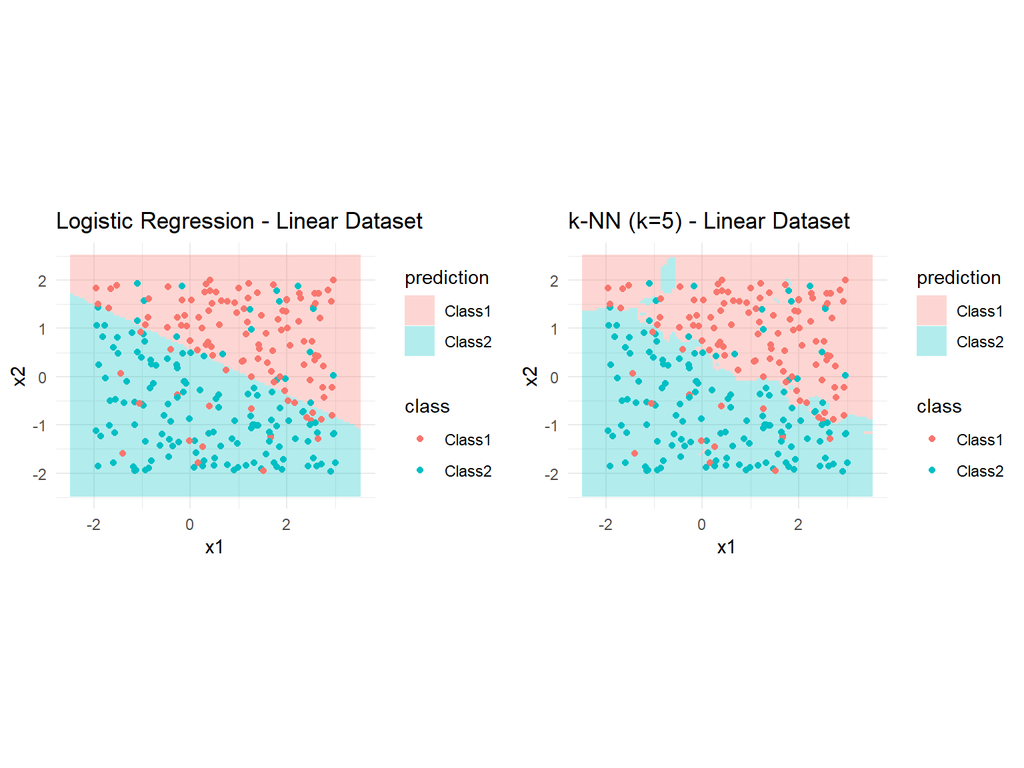

```r
# Choose the XOR dataset (most interesting) and visualize decision boundaries
visualize_boundaries <- function(data, title_suffix = "") {
  # Create prediction grid
  x1_seq <- seq(min(data$x1) - 0.5, max(data$x1) + 0.5, length.out = 100)
  x2_seq <- seq(min(data$x2) - 0.5, max(data$x2) + 0.5, length.out = 100)
  grid <- expand.grid(x1 = x1_seq, x2 = x2_seq)

  # Prepare training data (use all data for visualization)
  train_features <- data[, c("x1", "x2")]
  train_scaled <- scale(train_features)
  grid_scaled <- scale(grid,
                      center = attr(train_scaled, "scaled:center"),
                      scale = attr(train_scaled, "scaled:scale"))

  # Logistic regression predictions
  log_model <- glm(class ~ x1 + x2, data = data, family = binomial)
  log_pred_prob <- predict(log_model, grid, type = "response")
  log_pred <- ifelse(log_pred_prob > 0.5, levels(data$class)[2], levels(data$class)[1])

  # k-NN predictions
  knn_pred <- knn(train = train_scaled,
                 test = grid_scaled,
                 cl = data$class,
                 k = 5)

  # Create plots
  grid_log <- cbind(grid, prediction = factor(log_pred, levels = levels(data$class)))
  grid_knn <- cbind(grid, prediction = knn_pred)

  p_log <- ggplot() +
    geom_tile(data = grid_log, aes(x = x1, y = x2, fill = prediction), alpha = 0.3) +
    geom_point(data = data, aes(x = x1, y = x2, color = class), size = 1.5) +
    labs(title = paste("Logistic Regression", title_suffix)) +
    theme_minimal() + coord_fixed() +
    scale_fill_manual(values = c("#F8766D", "#00BFC4")) +
    scale_color_manual(values = c("#F8766D", "#00BFC4"))

  p_knn <- ggplot() +
    geom_tile(data = grid_knn, aes(x = x1, y = x2, fill = prediction), alpha = 0.3) +
    geom_point(data = data, aes(x = x1, y = x2, color = class), size = 1.5) +
    labs(title = paste("k-NN (k=5)", title_suffix)) +
    theme_minimal() + coord_fixed() +
    scale_fill_manual(values = c("#F8766D", "#00BFC4")) +
    scale_color_manual(values = c("#F8766D", "#00BFC4"))

  return(list(logistic = p_log, knn = p_knn))
}

# Visualize boundaries for all three datasets
plots_a <- visualize_boundaries(data_a, "- Linear Dataset")
plots_b <- visualize_boundaries(data_b, "- Circular Dataset")
plots_c <- visualize_boundaries(data_c, "- XOR Dataset")

# Display plots
grid.arrange(plots_a$logistic, plots_a$knn, ncol = 2)
```

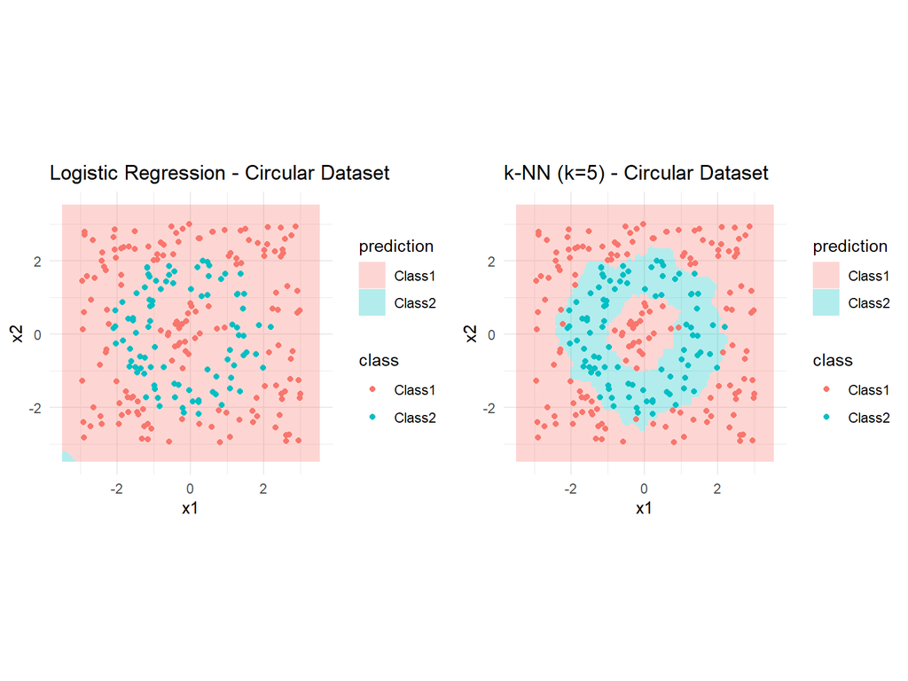

```r
grid.arrange(plots_b$logistic, plots_b$knn, ncol = 2)
```

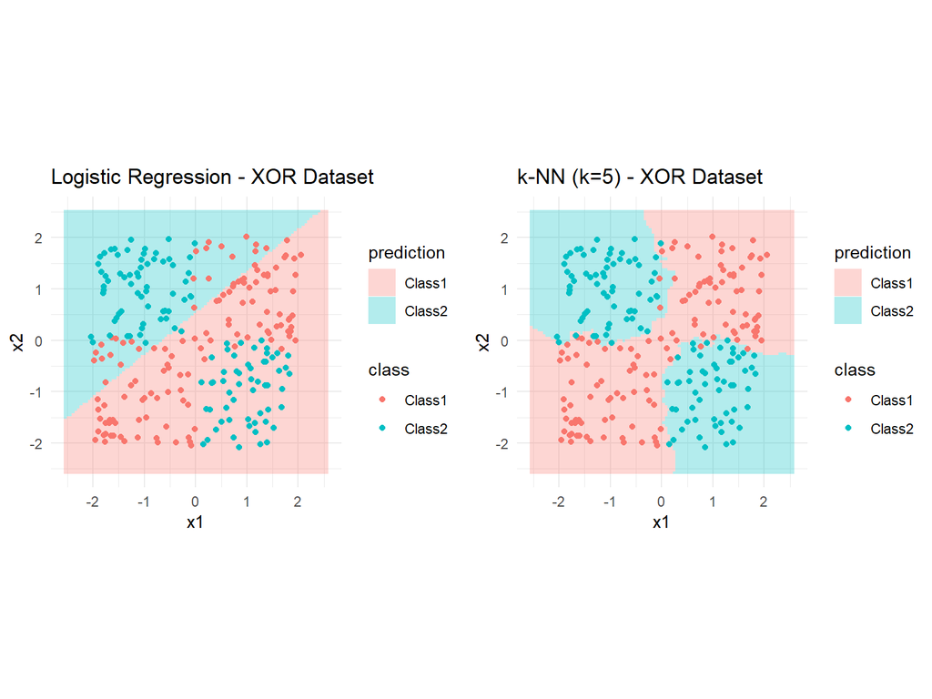

```r
grid.arrange(plots_c$logistic, plots_c$knn, ncol = 2)
```

## Reflection and Analysis (5 minutes)

Based on your results, answer these questions:

1. **Pattern Dependency**: Which patterns favor k-NN vs logistic regression? Why?

   **Answer**:
   - k-NN creates more flexible, jagged decision boundaries that follow local patterns
   - Logistic regression creates smooth, linear boundaries
   - k-NN can overfit with complex boundaries, while logistic regression might underfit complex patterns
3. **Practical Considerations**:
   - When would you choose k-NN over logistic regression in practice?
   - What are the computational trade-offs?

   **Answer**:
   - Choose k-NN when: relationships are clearly non-linear, you have sufficient data, interpretability is less important
   - Choose logistic regression when: you need interpretable coefficients, have limited data, relationships seem linear
   - **Computational trade-offs**: k-NN is slow at prediction time (must compute distances), logistic regression is fast once trained
4. **Scaling Impact**: Calculate the percentage improvement from scaling in Part 2. Why was it so dramatic?

   **Answer**:

   ```r
   scaling_improvement <- (accuracy_scaled - accuracy_unscaled) * 100
   print(paste("Scaling improved accuracy by", round(scaling_improvement, 1), "percentage points"))
   ```

   ```
   ## [1] "Scaling improved accuracy by 18.5 percentage points"
   ```

   ```r
   print("This is dramatic because income (in cents) completely dominated the distance calculation")
   ```

   ```
   ## [1] "This is dramatic because income (in cents) completely dominated the distance calculation"
   ```

   ```r
   print("Without scaling, test scores became irrelevant despite being predictive")
   ```

   ```
   ## [1] "Without scaling, test scores became irrelevant despite being predictive"
   ```

5. **Model Selection Challenge**: If you had to choose ONE method for each pattern type (linear, circular, XOR), what would you choose and why?

   **Answer**:
   - **Linear pattern**: Logistic Regression (simpler, interpretable, designed for linear boundaries)
   - **Circular pattern**: k-NN (naturally captures radial patterns)
   - **XOR pattern**: k-NN (logistic regression cannot handle XOR without feature engineering)

**Advanced Challenge**: What do you think would happen if you had 1000 features but only 50 observations?

```r
# Test high-dimensional, low-sample scenario
set.seed(600)
n_obs <- 50
n_features <- 100  # Use 100 instead of 1000 for computational efficiency

# Create high-dimensional data
high_dim_data <- data.frame(matrix(rnorm(n_obs * n_features), nrow = n_obs))
names(high_dim_data) <- paste0("X", 1:n_features)

# Create somewhat separable classes based on first few features
high_dim_data$class <- factor(ifelse(rowSums(high_dim_data[, 1:5]) > 0, "A", "B"))

# Compare methods with cross-validation (since dataset is small)
train_idx <- 1:35  # Use first 35 for training
test_idx <- 36:50  # Use last 15 for testing

train_features <- high_dim_data[train_idx, 1:n_features]
test_features <- high_dim_data[test_idx, 1:n_features]
train_labels <- high_dim_data$class[train_idx]
test_labels <- high_dim_data$class[test_idx]

# Scale features
train_scaled <- scale(train_features)
test_scaled <- scale(test_features,
                    center = attr(train_scaled, "scaled:center"),
                    scale = attr(train_scaled, "scaled:scale"))

# k-NN with different k values
k_values <- c(1, 3, 5, 10)
knn_results <- sapply(k_values, function(k) {
  pred <- knn(train = train_scaled, test = test_scaled, cl = train_labels, k = k)
  mean(pred == test_labels)
})

print("High-dimensional scenario results:")
```

```
## [1] "High-dimensional scenario results:"
```

```r
print("k-NN accuracies:")
```

```
## [1] "k-NN accuracies:"
```

```r
print(data.frame(k = k_values, accuracy = knn_results))
```

```
##    k  accuracy
## 1  1 0.6666667
## 2  3 0.7333333
## 3  5 0.7333333
## 4 10 0.6000000
```

```r
print("Challenge Answer: With many features and few observations:")
```

```
## [1] "Challenge Answer: With many features and few observations:"
```

```r
print("1. k-NN suffers from 'curse of dimensionality' - distances become meaningless")
```

```
## [1] "1. k-NN suffers from 'curse of dimensionality' - distances become meaningless"
```

```r
print("2. Need k << n, but even k=1 may overfit")
```

```
## [1] "2. Need k << n, but even k=1 may overfit"
```

```r
print("3. Feature selection or dimensionality reduction becomes crucial")
```

```
## [1] "3. Feature selection or dimensionality reduction becomes crucial"
```

```r
print("4. Logistic regression might actually perform better due to regularization")
```

```
## [1] "4. Logistic regression might actually perform better due to regularization"
```

## Key Takeaways

1. **k-NN is sensitive to the choice of k** - too small causes overfitting, too large causes underfitting
2. **Scaling is absolutely critical** for k-NN - features on different scales will dominate distance calculations
3. **Pattern complexity matters** - k-NN excels with non-linear patterns, logistic regression with linear relationships
4. **Computational trade-offs** - k-NN is expensive at prediction time, logistic regression after training is fast
5. **Dimensionality curse** - k-NN struggles as dimensionality increases relative to sample size

*You’ve now experienced the power and limitations of k-NN compared to parametric methods. Understanding when each method excels is crucial for real-world machine learning success!*